# BT1101 Practice Exam

1. | Maximize total return using decision variables $X_1$, $X_2$ | return = 19.2 $X_1$ + 21.9 $X_2$ |
   | --- | --- |
   | Subject to |  |
   | cost Constraint | 15.6 $X_1$ + 3.5 $X_2$ $\leq$ 1000000 |
   | risk Constraint | 0.37 $X_1$ + 18.21 $X_2$ $\leq$ 50000 |
   | Non-Negativity and Integer Constraint | $X_1$ $X_2$ are both integer and positive |

```r
objective.fn1 <- c(19.2,21.9)

const.mat1 <- matrix(c(15.6, 3.5,
                       0.37, 18.21),
                     ncol = 2,
                     byrow = TRUE)

const.dir1 <- c("<=","<=")
const.rhs1 <- c(1000000,50000)

lp.solution1 <- lp("max",objective.fn1, const.mat1 , const.dir1, const.rhs1, compute.sens = TRUE,all.int = TRUE)

lp.solution1
```

```
## Success: the objective function is 1256252
```

```r
lp.solution1$solution
```

```
## [1] 63777  1449
```

optimal return is $1256252 , this could be achieved by purchasing 63777 shares of 5X and 1449 shares of EG

Traffic Laws (total 15 marks) - Data set: `traffic2` in wooldridge.

```r
# load the data set, make sure you already load `wooldridge` package
data(traffic2)
tf <- traffic2
```

This data set contains 108 monthly time-series observations with 48 variables on state-wide traffic accidents. For this question, the relevant variables are the following:

year:1981 to 1989

totacc:total number of accidents

T:time trend

spdlaw= 1 after 65 mph law in effect

beltlaw= 1 after seatbelt law in effect

1. Traffic regulation policymaker is concerned if laws on speeding and wearing seatbelt have effect on the number of road accidents. Using the following four variables `totacc`, `t`, `spdlaw` and `beltlaw`, run a linear regression model to examine the relationship. Report the regression output and write out the fitted line. (4 marks)

```r
lm1 <- lm(totacc~t+spdlaw+beltlaw ,tf)

summary(lm1)
```

```
##
## Call:
## lm(formula = totacc ~ t + spdlaw + beltlaw, data = tf)
##
## Residuals:
##     Min      1Q  Median      3Q     Max
## -5459.5 -1756.3   -68.3  1657.9  5950.1
##
## Coefficients:
##             Estimate Std. Error t value Pr(>|t|)
## (Intercept) 37034.50     601.91  61.529  < 2e-16 ***
## t              80.29      16.82   4.775 5.91e-06 ***
## spdlaw      -1318.83     849.24  -1.553    0.123
## beltlaw      4076.69     937.97   4.346 3.23e-05 ***
## ---
## Signif. codes:  0 '***' 0.001 '**' 0.01 '*' 0.05 '.' 0.1 ' ' 1
##
## Residual standard error: 2440 on 104 degrees of freedom
## Multiple R-squared:  0.7274, Adjusted R-squared:  0.7196
## F-statistic: 92.51 on 3 and 104 DF,  p-value: < 2.2e-16
```

```r
##totacc = 37034.50 + 80.29 * t -1318.83 * spdlaw + 4076.69 * beltlaw
```

2. Interpret the coefficient estimators before `spdlaw` and `beltlaw`, respectively. (2 marks) Assuming the model is valid, please explain (by proposing possible theory) and make sense of the sign (direction of the effect) of coefficient estimators before `spdlaw` and `betlaw`. (2 marks)

spdlaw : -1318.83 :If the speed law is implemented and taken effect, it comes 1, the mean total number of road accidents is expected to decrease by 1318.83 on average than when it is not implemented.This is because limit the speed of the car can decrease the probability of accidents as drivers have more time to react to potential dangers and accidents. beltlaw : 4076.69 :If the belt law is implemented and taken effect, it comes 1, the mean total number of road accidents is expected to increase by 4076.69 on average than when it is not implemented. This is because drives tend to be more arrogant as they believe they are protected well by the belt so they drive more carelessly.

Limitation : The p value for spdlaw is larger than 0.05, means that at 5% level of significance, we do not have sufficient evidence to reject the null hypothesis that the coefficient is zero. Hence, spdlaw coefficient is statistically insignificant.

3. From your regression output alone without checking assumptions, why do you think we need to include the time trend `t` in the regression? (1 mark)

Yes. Number of vehicles on road increases as time progresses as cars are becoming necessities to people’s daily lives, and they are getting more and more affordable.

4. Now let’s single out the time series variable `totacc`, the monthly total number of accidents between 1981 and 1989.

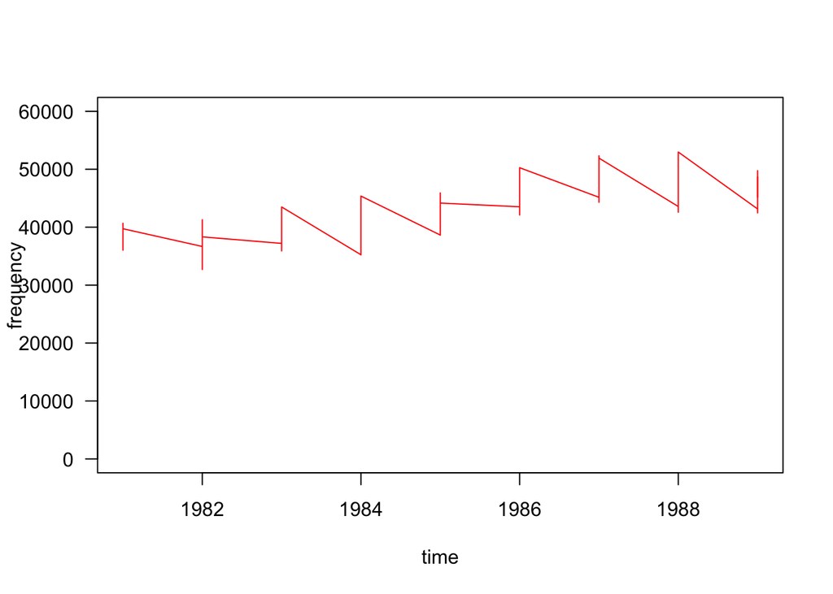

```r
# define `totacc` as a monthly time series object
tf1 = tf %>% mutate(totacc1=ts(traffic2$totacc, frequency = 12, start = 1981))

plot(tf1$year, tf1$totacc1, type = "l", col = "red",xlab = 'time', ylab= 'frequency',las=1, ylim= c(0,60000))
```

Plot the time series `totacc` and describe if the time series `totacc` shows any trend, seasonality or cyclicality. (3 marks)

There is an increasing trend as there is a general increasing movement. There are seasonal effects as there is a pattern that repeats itself at a regular time interval of one year.

5. Following the steps of best practice, identify an ARIMA model for univariate time series `totacc`. Provide justification with your proposed ARIMA model. Ignore the seasonality if any. (3 marks)